# [PRE-FINAL] miniproj4

## Condoms, FBI, and Jeffrey Epstein: Thematic Extraction of /AskReddit Comments in Reddit in 2019

*Analysis and notebook prepared by:*  
Master of Science in Data Science 2021  
Asian Institute of Management

EXECUTIVE SUMMARY

Reddit's **/AskReddit** is the most popular and most commented subreddit on the website. Plenty of personalities are interacting in the subreddit, thus plenty of themes could be from the corpus of comments. In classifying and identifying themes in the /AskReddit subreddit, we can determine how people behave based on how comment on posts. To analyze the data and get themes from it, the Reddit comments in the Jojie database was mined and everything pertaining to AskReddit comments in 2019 were saved in an SQL database. Afterwards, the comments were tokenized via TFIDF Vectorizer and saved to dataframe for further analysis. Then, using the Non-Negative Matrix Factorization, dimensions were reduced for easier analysis. The comments were clustered via K-Means Clustering. The clustering method yielded for 4 optimal clusters which could be attributed to the following themes:

1. General Questions About Daily Life
2. Questions about Sex and Pleasure
3. Conspiracy Questions Specifically About the US Government and Jeffrey Epstein
4. Bot-Related Comments or Statements

For the year 2019, it is therefore believed that the comments and questions on the /AskReddit subreddit cluster into one of these four themes.

INTRODUCTION

Reddit, the frontpage of the internet, is a forum-style website that aggregates several topics such as politics, games, nature, and things as mundane as ghosts, 4th dimension, among others. These topics are organized into smaller forums within the website called "subreddit" and one important subreddit that new users must get into first is the **AskReddit** subreddit. This subreddit contains information on how to post questions on reddit and basically ask any question they have on their minds.

Since, Askreddit is the top subreddit in terms of comment count, the richness of text data in the Askreddit subreddit is a goldmine waiting to be analyzed. One such way of analyzing the comments in the said subreddit is through the use of *theme extraction*. This form of analysis allows us to determine how user behave in the said subreddit on a given time, thus the emergence of themes. What do people in this subreddit talk about?

The dataset used in this analysis came from the corpus of comments of Reddit from the Jojie database. The dataset will be described in detail in the latter part of this analysis.

VALUE

In determining the themes of the AskReddit, this analysis can provide ways on how the subreddit can be managed from an admin and business standpoint.

1. **Admin**
   - If emerging themes are good, the admin can capitilize on this by making sure this atmosphere is maintained within the subreddit. For example, they can give more and more incentives like stars or reddit gold to keep the subreddit alive. If the themes are harmful and bad, they can enforce more rules to make the subreddit more safe especially for underaged users.
2. **Business**
   - Forum advertisements are very much a practice in reddit. Business can use the emergent themes to their advantage. They can position their marketing efforts to suit the feeling and theme of the subreddit.

PROBLEM STATEMENT

With this analysis, we aim to answer the question: **Would themes emerge from the comments in /Askreddit?** Moreover, what are these themes?

DATA PREPARATION

Specific libraries are loaded for clustering and analysis are loaded at the start of this notebook to make sure the methods and functions to be used later on will work properly.

```python
import pandas as pd
import sqlite3
import numpy as np
import pandas as pd

from sklearn.feature_extraction.text import TfidfVectorizer
from tqdm import tqdm
import time
from sklearn.metrics import confusion_matrix, recall_score, precision_score
import matplotlib.pyplot as plt
import seaborn as sns
import re
from sklearn.feature_extraction import text
from collections import Counter
from sklearn.decomposition import NMF
from wordcloud import WordCloud, STOPWORDS

from sklearn.preprocessing import normalize
from sklearn.cluster import KMeans, DBSCAN, OPTICS
from sklearn.metrics import calinski_harabasz_score, silhouette_score
from tqdm import tqdm
from scipy.spatial.distance import euclidean, cityblock
from sklearn import preprocessing
from sklearn.decomposition import PCA, TruncatedSVD
from sklearn.metrics.pairwise import cosine_similarity
from gensim.corpora import Dictionary
from gensim.models.nmf import Nmf
from gensim.models.coherencemodel import CoherenceModel
```

```python
def pooled_within_ssd(X, y, centroids, dist):
    """Compute pooled within-cluster sum of squares around the cluster mean

    Parameters
    ----------
    X : array
        Design matrix with each row corresponding to a point
    y : array
        Class label of each point
    centroids : array
        Number of pairs to sample
    dist : callable
        Distance between two points. It should accept two arrays, each
        corresponding to the coordinates of each point

    Returns
    -------
    float
        Pooled within-cluster sum of squares around the cluster mean
    """
    n = np.bincount(y)
    count = 0

    for x, y in zip(X,y):
        count += (1/(2*n[y]))*dist(x, centroids[y])**2

    return count

def gap_statistic(X, y, centroids, dist, b, clusterer, random_state=None):
    """Compute the gap statistic

    Parameters
    ----------
    X : array
        Design matrix with each row corresponding to a point
    y : array
        Class label of each point
    centroids : array
        Number of pairs to sample
    dist : callable
        Distance between two points. It should accept two arrays, each
        corresponding to the coordinates of each point
    b : int
        Number of realizations for the reference distribution
    clusterer : KMeans
        Clusterer object that will be used for clustering the reference
        realizations
    random_state : int, default=None
        Determines random number generation for realizations

    Returns
    -------
    gs : float
        Gap statistic
    gs_std : float
        Standard deviation of gap statistic
    """

    rng = np.random.default_rng(random_state)
    minimum = X.min(0)
    maximum = X.max(0)
    W_k = np.log(pooled_within_ssd(X, y, centroids, dist))

    log_wk = []
    for i in range(b):

        clusterer.set_params(n_clusters=len(centroids))

        X_i = rng.uniform(minimum, maximum, size=X.shape)

        y_i = clusterer.fit_predict(X_i)
        log_wk.append(np.log(pooled_within_ssd(X_i, y_i,
                                               clusterer.cluster_centers_,
                                               dist)))

    return [np.mean(log_wk - W_k), np.std(log_wk - W_k)]

def cluster_range(X, clusterer, k_start, k_stop, actual=None):
    """Compute cluster statistics"""
    ys = []
    inertias = []
    chs = []
    scs = []
    gss = []
    gssds = []

    for k in tqdm(range(k_start, k_stop+1)):

        clusterer.set_params(n_clusters=k)
        y = clusterer.fit_predict(X)
        ys.append(y)
        inertias.append(clusterer.inertia_)
        chs.append(calinski_harabasz_score(X, y))
        scs.append(silhouette_score(X, y))

        if actual is not None:
            ps.append(purity(actual, y))
            amis.append(adjusted_mutual_info_score(actual, y))
            ars.append(adjusted_rand_score(actual, y))

        gs = gap_statistic(X, y, clusterer.cluster_centers_,
                                 euclidean, 5,
                                 clusterer.set_params(n_clusters=k),
                                 random_state=1337)
        gss.append(gs[0])
        gssds.append(gs[1])

    return_dict = {'ys' : ys, 'inertias' : inertias, 'chs' : chs,
                   'gss' : gss, 'gssds' : gssds, 'scs' : scs}

    if actual is not None:
        return_dict['ps'] = ps
        return_dict['amis'] = amis
        return_dict['ars'] = ars

    return return_dict

def plot_clusters(X, ys):
    """Plot clusters given the design matrix and cluster labels"""
    k_max = len(ys) + 1
    k_mid = k_max//2 + 2
    fig, ax = plt.subplots(2, k_max//2, dpi=150, sharex=True, sharey=True,
                           figsize=(7,4), subplot_kw=dict(aspect='equal'),
                           gridspec_kw=dict(wspace=0.01))
    for k,y in zip(range(2, k_max+1), ys):
        if k < k_mid:
            ax[0][k%k_mid-2].scatter(*zip(*X), c=y, s=1, alpha=0.8)
            ax[0][k%k_mid-2].set_title('$k=%d$'%k)
        else:
            ax[1][k%k_mid].scatter(*zip(*X), c=y, s=1, alpha=0.8)
            ax[1][k%k_mid].set_title('$k=%d$'%k)
    return ax

def plot_internal(inertias, chs, scs, gss, gssds):
    """
    Plot internal validation values
    """
    fig, ax = plt.subplots(4,1,dpi=100, figsize=(8,12))
    plt.subplots_adjust(hspace=.3)
    ks = np.arange(2, len(inertias)+2)
    ax[0].plot(ks, inertias, '-o', label='SSE', c='#fd5c63')
    ax[1].plot(ks, chs, '-o', label='CH', c='#fd5c63')
    ax[0].set_xlabel('$k$')
    ax[1].set_xlabel('$k$')
    ax[2].plot(ks, gss, '-o', label='Gap statistic', color = '#fd5c63')
    ax[3].plot(ks, scs, '-o', label='Silhouette coefficient', c='#fd5c63')
    ax[2].set_xlabel('$k$')
    ax[3].set_xlabel('$k$')
    ax[0].legend()
    ax[1].legend()
    ax[2].legend()
    ax[3].legend()
    return ax
```

DATASET

The dataset was mined from the Jojie database. This dataset consists of comments from almost all subreddits in reddit. Due to the large size of the dataset, the mined data was saved in an SQL database for easier manipulation.

Afterwards, the data was pulled from the SQL and using a combination of a Pandas function and an SQL command, data was filtered to only get comments pertaining to the `AskReddit` subreddit.

```python
conn = sqlite3.connect('reddit.db')
c = conn.cursor()

df = pd.read_sql("""SELECT body, created_utc FROM comments
                WHERE "subreddit" = 'AskReddit'
                """, conn)
df = df.astype(str)

df = df.drop('created_utc', axis=1)
```

```python
display(df.head())
```

|  | body |
| --- | --- |
| 0 | **PLEASE READ THIS MESSAGE IN ITS ENTIRETY BEF... |
| 1 | [deleted] |
| 2 | Well, I would first question who is defining w... |
| 3 | Babies came out of your belly button when they... |
| 4 | One thing I don't see the media mentioning at ... |

**Figure 1: The /AskReddit Dataset**

No further wrangling was done to the dataset as we need the comments in it's entirety. Cleaning will be done later on when dimensionality reduction and clustering will be done. Thus, the data set only consist of the following feature:

| feature | description |
| --- | --- |
| body | comments pertaining to the askreddit subreddit |

**Figure 2: Data Description for Askreddit Corpus**

PIPELINE

In the analysis of the Askreddit comments dataset, the following steps will be undertaken:

1. Tokenizing via TFIDF and create a bag of words of the tokenized dataset
2. Reduce the dimensions of the dataset using NMF
3. Normalize bag of words using cosine similarity
4. Perform clustering via K-Means Clustering
5. Identify optimal clusters
6. Analyze topics in the clusters via wordcloud and identify themes

The following steps in the pipeline is done below.

#### 1. Tokenizing via TFIDF and create a bag of words of the tokenized dataset

TF-IDF (Term Frequency, Inverse-Document Frequency) is a measure of how words are relevant words are in a dataset. A sparse matrix with the relevance score is returned in a dataframe.

*NOTE 1:* Each row in the dataframe pertains to a comment.  
*NOTE 2:* Some common words such as particles and prepositions are removed via the STOPWORDS function in the TFIDF Vectorizer as well as common nonsensical words like `www`, `com` which pertains to website links and commonly appearing words like `reddit` which is redundant.

```python
stopwords = text.ENGLISH_STOP_WORDS.union(['deleted', 'removed',
                                           'know', 'what', 'just',
                                           'like', 'www', 'http', 'askreddit',
                                           'subreddit', 'com', 'reddit',
                                           'but', 'https'])

# use tfid vectorizer to convert words in columns
tfidf = TfidfVectorizer(sublinear_tf=True, max_df=.90, min_df=11, norm='l2',
                        encoding='latin-1', ngram_range=(1,1),
                        stop_words= stopwords)

bow = tfidf.fit_transform(df['body']).toarray() #extract features
```

```python
bow.shape
```

```
(4206, 738)
```

**Figure 3: Shape of the dataset**

#### 2. Reduce the dimensions of the dataset using NMF

Because of the large shape of the dataset and since the TFIDF returns a sparse matrix with a `min` of 0 per each word and no negative values are found, the best way to reduce the dimensionality of this dataset is to use `Non-Negative Matrix Factorization` or NMF.

```python
nmf = NMF(n_components=14, random_state=1337, alpha=.1).fit(bow)
nmf_output = nmf.fit_transform(bow)
```

```python
def show_topics(vectorizer=tfidf, lda_model=nmf, n_words=20):
    """Get keywords for each topic"""
    keywords = np.array(vectorizer.get_feature_names())
    topic_keywords = []
    for topic_weights in lda_model.components_:
        top_keyword_locs = (-topic_weights).argsort()[:n_words]
        topic_keywords.append(keywords.take(top_keyword_locs))
    return topic_keywords

topic_keywords = show_topics(vectorizer=tfidf, lda_model=nmf, n_words=20)
```

```python
df_topic_keywords = pd.DataFrame(topic_keywords)
df_topic_keywords.columns = ['Word '+str(i) for i in range(df_topic_keywords
                                                           .shape[1])]
df_topic_keywords.index = ['Topic '+str(i) for i in range(df_topic_keywords
                                                          .shape[0])]
```

```python
df_topic_keywords
```

|  | Word 0 | Word 1 | Word 2 | Word 3 | Word 4 | Word 5 | Word 6 | Word 7 | Word 8 | Word 9 | Word 10 | Word 11 | Word 12 | Word 13 | Word 14 | Word 15 | Word 16 | Word 17 | Word 18 | Word 19 |
| --- | --- | --- | --- | --- | --- | --- | --- | --- | --- | --- | --- | --- | --- | --- | --- | --- | --- | --- | --- | --- |
| Topic 0 | make | actually | way | said | work | sure | right | things | doesn | day | isn | look | going | better | ll | real | school | pretty | thought | makes |
| Topic 1 | post | question | message | questions | title | action | compose | rule | concerns | contact | wiki | index | wiki_ | automatically | bot | performed | moderators | amp | hi | rule_1 |
| Topic 2 | don | need | maybe | eat | kids | ask | care | want | software | man | try | make | god | wouldn | weird | haha | fish | understand | fuck | hate |
| Topic 3 | people | world | lot | play | wear | live | reason | things | thing | fucking | getting | mean | usually | need | enjoy | real | kinda | add | general | job |
| Topic 4 | good | sounds | long | yeah | pretty | hear | point | food | job | thanks | looking | thing | house | place | try | bad | music | ll | probably | years |
| Topic 5 | time | shit | long | try | nice | hand | oh | away | didn | phone | fear | sleep | looking | turn | toilet | right | years | hours | trump | listen |
| Topic 6 | think | need | better | old | lot | evidence | lost | friend | bad | test | fact | making | guys | having | fuck | used | power | great | wasn | went |
| Topic 7 | did | eat | friend | years | god | say | point | wait | book | called | movie | definitely | exactly | look | 11 | basically | big | conversation | question | went |
| Topic 8 | lol | sounds | thought | maybe | didn | hell | big | cheese | definitely | school | obviously | state | kinda | question | thing | law | super | feel | fuck | paper |
| Topic 9 | ve | say | heard | seen | thank | got | said | times | true | friends | met | different | yeah | thing | days | test | second | point | calls | tried |
| Topic 10 | life | youtu | vlfevaftmkk | meaning | live | living | children | true | baby | dick | purpose | experience | imagine | reason | way | fucking | state | end | couldn | kids |
| Topic 11 | want | got | didn | kids | ask | used | learn | world | older | wife | realized | police | thing | kill | shit | sex | hell | piece | eating | believe |
| Topic 12 | love | thanks | man | probably | nice | shit | wear | god | dad | support | used | exactly | better | totally | lot | great | girl | try | multiple | cheese |
| Topic 13 | really | bad | cool | way | lot | cause | new | used | thing | care | wow | ones | gets | fuck | quite | mean | interesting | dark | media | getting |

**Figure 4: Dataframe of latent topics when NMF is used**

The topics extracted when NMF is utilized seemed to be all over the place. No obvious themes could be extracted. The next possible thing to do is to cluster the NMF reduced TFIDF via K-Means.

#### 3. Normalize bag of words using cosine similarity

This time, the dataset is still reduced via NMF but with an added component in the form of **Cosine Similarity**. Cosine similarity is a similarity metric used to measure how documents are similar to each other **REGARDLESS** of their size. Cosine similarity is advantageous since we are using text data and even though they are far apart via Euclidean distance because of their size, they could still have a small angle between. It is believed that the smaller the angle, the smaller more similar the documents.

```python
w1 = preprocessing.normalize(nmf_output, norm = 'l2', axis = 1)
```

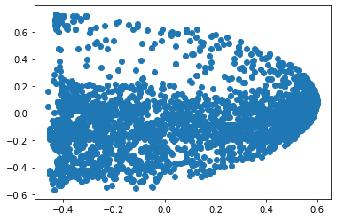

```python
X_new = PCA(n_components=2, random_state=1337).fit_transform(w1)
plt.scatter(X_new[:,0], X_new[:,1]);
```

**Figure 5: Scatterplot of NMF Reduced dataset with Cosine Similarity.**

#### 4. Perform clustering via K-Means Clustering

Clustering is performed on the NMF reduced dataset to find out if themes will emerge from these clausters.

```python
res_reddit = cluster_range(X_new, KMeans(random_state=1337), 2, 11)
```

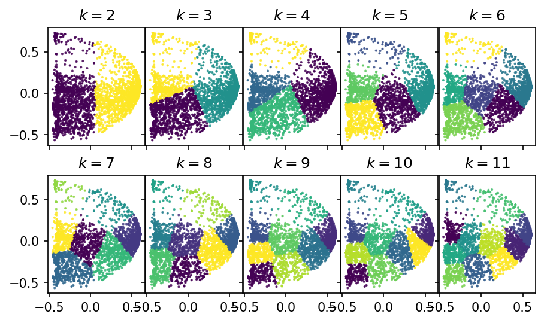

```python
plot_clusters(X_new, res_reddit['ys']);
```

**Figure 6: Visual Representation of k clusters from 2 to 11**

#### 5. Identify optimal clusters

By visual inspection, it looks like the choice of optimal clusters are between $k$=3 and $k$=4. To finalize the choice we will perform some internal validation criteria.

```
array([<matplotlib.axes._subplots.AxesSubplot object at 0x7ff7640f52d0>,
      dtype=object)
```

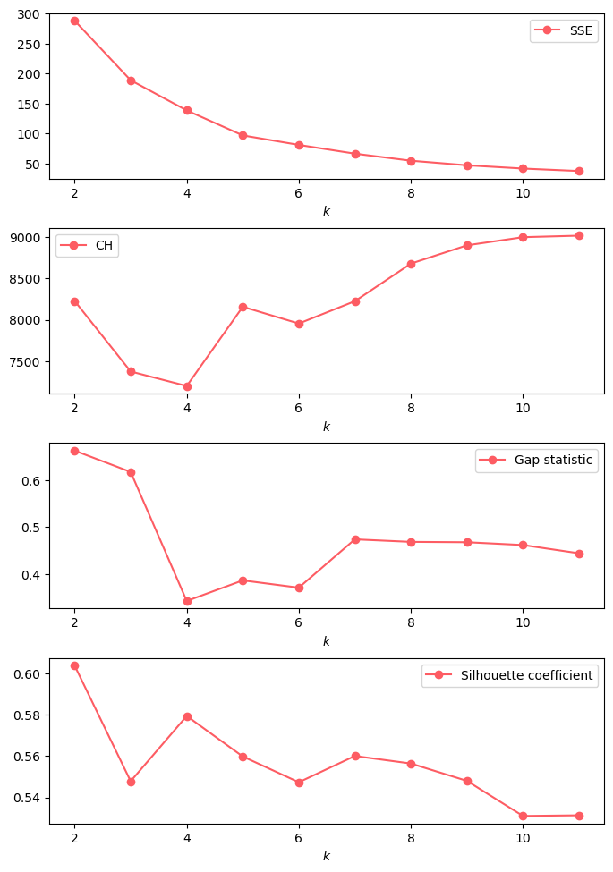

```python
plot_internal(res_reddit['inertias'], res_reddit['chs'], res_reddit['scs'],
              res_reddit['gss'], res_reddit['gssds'])
```

**Figure 7: Internal Validation Graphs**

From the graphs shown above, the following are the optimal clusters based on their results:

By majority rule, $k$=2 is the optimal choice. This however didn't prove to be a good generalization for themes later on. By visual confirmation, we will be choosing $k$=4 as the optimal k.

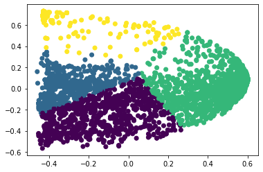

```python
kmeans_ng = KMeans(n_clusters=4, random_state=1)
y_predict_ng = kmeans_ng.fit_predict(X_new)
plt.scatter(X_new[:,0], X_new[:,1], c=y_predict_ng);
```

**Figure 8: k-Means Cluster with $k$=4.**

#### 6. Analyze topics in the clusters via wordcloud and identify themes

The clustering yielded good clusters. Since it's unsupervised though, we don't know the results of the clusters. Visually, clusters are parsimonius. We are expecting latent themes to emerge.

```python
df['cluster'] = y_predict_ng
```

```python
df.groupby('cluster')['cluster'].count()
```

```
cluster
0     876
1    1559
2    1589
3     182
Name: cluster, dtype: int64
```

**Figure 9: Cluster Distribution**

### Theme 1: General Questions

The first clusters are related to general questions relating to how or what people are currently thinking or doing. Comments to questions like "What are people doing this year?" or "What do you want to do when you're bored" are abundant in this cluster.

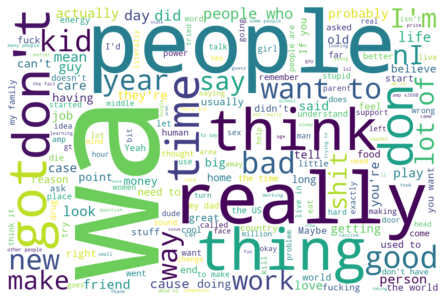

```python
zero = df[df['cluster']==0]['body']
z = zero.values


wordcloud = WordCloud(width = 1200, height = 800,
                background_color ='white',
                stopwords = stopwords,
                min_font_size = 10).generate(str(z))

plt.imshow(wordcloud, interpolation = 'bilinear')
plt.axis('off')
plt.tight_layout(pad=0)
plt.show()
```

**Figure 10: Cluster 1 Common Words**

### Theme 2: Questions and Comments about Sex and Pleasure

The second cluster is related to sex and pleasure. Comments to question like "What condom do you wear?" are abundant in this cluster.

One might be wondering why Nike is here. Since the motto of Nike is "just do it," people are alluding this to efforts on having sex. People would ask "when should I have sex?", most of the comments would say, "Like Nike, just do it".

[figure not shown]

```python
zero = df[df['cluster']==1]['body']
z = zero.values


wordcloud = WordCloud(width = 1200, height = 800,
                background_color ='black',
                stopwords = stopwords,
                min_font_size = 10).generate(str(z))

plt.imshow(wordcloud, interpolation = 'bilinear')
plt.axis('off')
plt.tight_layout(pad=0)
plt.show()
```

**Figure 11: Cluster 2 Common Words**

### Theme 3: Conspiracy Questions Specifically About the US Government and Jeffrey Epstein

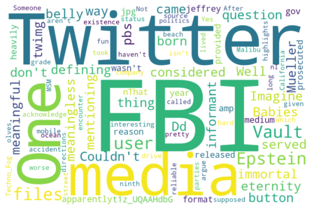

```python
zero = df[df['cluster']==2]['body']
z = zero.values


wordcloud = WordCloud(width = 1200, height = 800,
                background_color ='white',
                stopwords = stopwords,
                min_font_size = 10).generate(str(z))

plt.imshow(wordcloud, interpolation = 'bilinear')
plt.axis('off')
plt.tight_layout(pad=0)
plt.show()
```

**Figure 12: Cluster 3 Common Words**

### Theme 4: Bot Related Comments or Statements

The algorithm was able to segregate the comments and statements made by bots. Most of these comments and posts are instructions on how to use the askreddit subreddit.

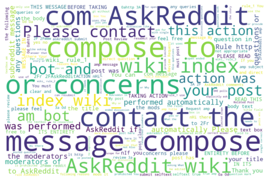

```python
zero = df[df['cluster']==3]['body']
z = zero.values

wordcloud = WordCloud(width = 1200, height = 800,
                background_color ='white',
                stopwords = stopwords,
                min_font_size = 10).generate(str(z))

plt.imshow(wordcloud, interpolation = 'bilinear')
plt.axis('off')
plt.tight_layout(pad=0)
plt.show()
```

**Figure 13: Cluster 4 Common Words**

CONCLUSION

From our analysis above, themes have emerged after using the clustering method that was performed. Four themes have emerged, and the clusters very much reflect what the AskReddit is. The clusters have captured how the comments are supposed to be categorized. Thus, we therefore conclude that there are emergent themes in the AskReddit subreddit and the following 4 clusters with themes have appeared:

1. General Questions About Daily Life
2. Questions about Sex and Pleasure
3. Conspiracy Questions Specifically About the US Government and Jeffrey Epstein
4. Bot-Related Comments or Statements

RECOMMENDATION

For further study, the performed analysis can be tried in the other subreddits in reddit. Clustering can also be performed per subreddit instead of performing it within the subreddits. In this way, similar subreddits can be grouped together and admin can implement rules across similarly themed subreddits.

REFERENCES

- Aggarwal, Charu **Data Mining: The Textbook** Springer International Publishing, 2015
- Geron, Aurelien **Hands-on Machine Learning with Scikit-Learn, Keras & TensorFlow: Concepts, Tools, and Techniques to Build Intelligent Systems** O'Reilly Media, Inc., 2019
- The Value of Text Mining for Unstructured Information: https://expertsystem.com/value-text-mining-unstructured-information/
- Nelson, Paul **Natural Language Processing (NLP) Techniques for Extracting Information** https://www.searchtechnologies.com/blog/natural-language-processing-techniques
- Prabhakaran, Elva **Cosine Similarity – Understanding the math and how it works (with python codes)** https://www.machinelearningplus.com/nlp/cosine-similarity/
- Khan, Tanveer **Relationship between Cosine Similarity and Euclidean Distance** https://medium.com/ai-for-real/relationship-between-cosine-similarity-and-euclidean-distance-7e283a277dff